# Barplot_Sid_Sym_C

Veronica Radice

07/05/2021

# Barplots of Differentially expressed genes

## Coral symbionts - *Cladocopium*

### Import libraries

```r
library(ggplot2)
library(scales)
library(dplyr)
library(plyr)
```

### Resources

https://stackoverflow.com/questions/38268741/geom-bar-ggplot2-stacked-grouped-bar-plot-with-positive-and-negative-values-p

### Set working directory

```r
setwd("~/Documents/Rprojects/postdoc\ Rprojects/ODU_postdoc_Rprojects/Paper_Ojo_gene-expression/Siderastrea/symbiont/")
```

# Effect of Destination Control

Absolute number of DEG adjusted p-value < 0.1

```r
# import data
de.genes <- readRDS("Sid_Symbiont_DE_genes_OC_LC_padj.1.rds")

# add group pairwise contrast label
de.genes$group <- 'OC-LC'
de.genes$group <- as.factor(de.genes$group)
```

### Count which genes are Upregulated versus Downregulated

LFC = log2FoldChange

```r
de.genes$LFC <- ifelse(de.genes$log2FoldChange>0, 'Up', 'Down')
de.genes$LFC <- as.factor(de.genes$LFC)

summary_DEG <- de.genes %>% dplyr::count(group, LFC)
summary_DEG$LFC <- factor(summary_DEG$LFC, levels = c("Up", "Down"))

summary_DEG[1,3] <- summary_DEG[1,3]*(-1)

summary_DEG_1 <- summary_DEG

summary_DEG_1
```

```
## # A tibble: 2 x 3
##   group LFC       n
##   <fct> <fct> <int>
## 1 OC-LC Down    -10
## 2 OC-LC Up        3
```

Absolute number of DEG adjusted p-value < 0.1

```r
# import data
de.genes <- readRDS("Sid_Symbiont_DE_genes_OC_RC_padj.1.rds")

# add group pairwise contrast label
de.genes$group <- 'OC-RC'
de.genes$group <- as.factor(de.genes$group)
dim(de.genes)
```

```
## [1] 5636    8
```

### Count which genes are Upregulated versus Downregulated

LFC = log2FoldChange

```r
de.genes$LFC <- ifelse(de.genes$log2FoldChange>0, 'Up', 'Down')
de.genes$LFC <- as.factor(de.genes$LFC)

summary_DEG <- de.genes %>% dplyr::count(group, LFC)
summary_DEG$LFC <- factor(summary_DEG$LFC, levels = c("Up", "Down"))

summary_DEG[1,3] <- summary_DEG[1,3]*(-1)

summary_DEG_2 <- summary_DEG
summary_DEG_2
```

```
## # A tibble: 2 x 3
##   group LFC       n
##   <fct> <fct> <int>
## 1 OC-RC Down  -5439
## 2 OC-RC Up      197
```

Absolute number of DEG adjusted p-value < 0.1

```r
# import data
de.genes <- readRDS("Sid_Symbiont_DE_genes_LC_RC_padj.1.rds")

# add group pairwise contrast label
de.genes$group <- 'LC-RC'
de.genes$group <- as.factor(de.genes$group)
dim(de.genes)
```

```
## [1] 3014    8
```

### Count which genes are Upregulated versus Downregulated

LFC = log2FoldChange

```r
de.genes$LFC <- ifelse(de.genes$log2FoldChange>0, 'Up', 'Down')
de.genes$LFC <- as.factor(de.genes$LFC)

summary_DEG <- de.genes %>% dplyr::count(group, LFC)
summary_DEG$LFC <- factor(summary_DEG$LFC, levels = c("Up", "Down"))

summary_DEG[1,3] <- summary_DEG[1,3]*(-1)

summary_DEG_3 <- summary_DEG
summary_DEG_3
```

```
## # A tibble: 2 x 3
##   group LFC       n
##   <fct> <fct> <int>
## 1 LC-RC Down  -2831
## 2 LC-RC Up      183
```

# Effect of Destination Ojo

Absolute number of DEG adjusted p-value < 0.1

```r
# import data
de.genes <- readRDS("Sid_Symbiont_DE_genes_OO_LO_padj.1.rds")

# add group pairwise contrast label
de.genes$group <- 'OO-LO'
de.genes$group <- as.factor(de.genes$group)
```

### Count which genes are Upregulated versus Downregulated

LFC = log2FoldChange

```r
de.genes$LFC <- ifelse(de.genes$log2FoldChange>0, 'Up', 'Down')
de.genes$LFC <- as.factor(de.genes$LFC)

summary_DEG <- de.genes %>% dplyr::count(group, LFC)
summary_DEG$LFC <- factor(summary_DEG$LFC, levels = c("Up", "Down"))

summary_DEG[1,3] <- summary_DEG[1,3]*(-1)

summary_DEG_4 <- summary_DEG
summary_DEG_4
```

```
## # A tibble: 2 x 3
##   group LFC       n
##   <fct> <fct> <int>
## 1 OO-LO Down     -9
## 2 OO-LO Up       63
```

Absolute number of DEG adjusted p-value < 0.1

```r
# import data
de.genes <- readRDS("Sid_Symbiont_DE_genes_LO_RO_padj.1.rds")

# add group pairwise contrast label
de.genes$group <- 'LO-RO'
de.genes$group <- as.factor(de.genes$group)
dim(de.genes)
```

```
## [1] 227   8
```

### Count which genes are Upregulated versus Downregulated

LFC = log2FoldChange

```r
de.genes$LFC <- ifelse(de.genes$log2FoldChange>0, 'Up', 'Down')
de.genes$LFC <- as.factor(de.genes$LFC)

summary_DEG <- de.genes %>% dplyr::count(group, LFC)
summary_DEG$LFC <- factor(summary_DEG$LFC, levels = c("Up", "Down"))

summary_DEG[1,3] <- summary_DEG[1,3]*(-1)

summary_DEG_5 <- summary_DEG
summary_DEG_5
```

```
## # A tibble: 2 x 3
##   group LFC       n
##   <fct> <fct> <int>
## 1 LO-RO Down    -91
## 2 LO-RO Up      136
```

Absolute number of DEG adjusted p-value < 0.1

```r
# import data
de.genes <- readRDS("Sid_Symbiont_DE_genes_OO_RO_padj.1.rds")

# add group pairwise contrast label
de.genes$group <- 'OO-RO'
de.genes$group <- as.factor(de.genes$group)
dim(de.genes)
```

```
## [1] 2926    8
```

### Count which genes are Upregulated versus Downregulated

LFC = log2FoldChange

```r
de.genes$LFC <- ifelse(de.genes$log2FoldChange>0, 'Up', 'Down')
de.genes$LFC <- as.factor(de.genes$LFC)

summary_DEG <- de.genes %>% dplyr::count(group, LFC)
summary_DEG$LFC <- factor(summary_DEG$LFC, levels = c("Up", "Down"))

summary_DEG[1,3] <- summary_DEG[1,3]*(-1)

summary_DEG_6 <- summary_DEG
summary_DEG_6
```

```
## # A tibble: 2 x 3
##   group LFC       n
##   <fct> <fct> <int>
## 1 OO-RO Down  -2755
## 2 OO-RO Up      171
```

# Ojo vs Control (same origins)

Absolute number of DEG adjusted p-value < 0.1

```r
# import data
de.genes <- readRDS("Sid_Symbiont_DE_genes_LO_LC_padj.1.rds")

# add group pairwise contrast label
de.genes$group <- 'LO-LC'
de.genes$group <- as.factor(de.genes$group)
dim(de.genes)
```

```
## [1] 60  8
```

### Count which genes are Upregulated versus Downregulated

LFC = log2FoldChange

```r
de.genes$LFC <- ifelse(de.genes$log2FoldChange>0, 'Up', 'Down')
de.genes$LFC <- as.factor(de.genes$LFC)

summary_DEG <- de.genes %>% dplyr::count(group, LFC)
summary_DEG$LFC <- factor(summary_DEG$LFC, levels = c("Up", "Down"))

summary_DEG[1,3] <- summary_DEG[1,3]*(-1)

summary_DEG_7 <- summary_DEG
summary_DEG_7
```

```
## # A tibble: 2 x 3
##   group LFC       n
##   <fct> <fct> <int>
## 1 LO-LC Down    -57
## 2 LO-LC Up        3
```

Absolute number of DEG adjusted p-value < 0.1

```r
# import data
de.genes <- readRDS("Sid_Symbiont_DE_genes_OO_OC_padj.1.rds")

# add group pairwise contrast label
de.genes$group <- 'OO-OC'
de.genes$group <- as.factor(de.genes$group)
dim(de.genes)
```

```
## [1] 42  8
```

### Count which genes are Upregulated versus Downregulated

LFC = log2FoldChange

```r
de.genes$LFC <- ifelse(de.genes$log2FoldChange>0, 'Up', 'Down')
de.genes$LFC <- as.factor(de.genes$LFC)

summary_DEG <- de.genes %>% dplyr::count(group, LFC)
summary_DEG$LFC <- factor(summary_DEG$LFC, levels = c("Up", "Down"))

summary_DEG[1,3] <- summary_DEG[1,3]*(-1)

summary_DEG_8 <- summary_DEG
summary_DEG_8
```

```
## # A tibble: 2 x 3
##   group LFC       n
##   <fct> <fct> <int>
## 1 OO-OC Down     -9
## 2 OO-OC Up       33
```

Absolute number of DEG adjusted p-value < 0.1

```r
# import data
de.genes <- readRDS("Sid_Symbiont_DE_genes_RO_RC_padj.1.rds")

# add group pairwise contrast label
de.genes$group <- 'RO-RC'
de.genes$group <- as.factor(de.genes$group)
dim(de.genes)
```

```
## [1] 9 8
```

### Count which genes are Upregulated versus Downregulated

LFC = log2FoldChange

```r
de.genes$LFC <- ifelse(de.genes$log2FoldChange>0, 'Up', 'Down')
de.genes$LFC <- as.factor(de.genes$LFC)

summary_DEG <- de.genes %>% dplyr::count(group, LFC)
summary_DEG$LFC <- factor(summary_DEG$LFC, levels = c("Up", "Down"))

summary_DEG[1,3] <- summary_DEG[1,3]*(-1)

summary_DEG_9 <- summary_DEG
summary_DEG_9
```

```
## # A tibble: 2 x 3
##   group LFC       n
##   <fct> <fct> <int>
## 1 RO-RC Down     -1
## 2 RO-RC Up        8
```

# Effect of overall low pH vs. ambient pH

*However, no comparison of sites*

Absolute number of DEG adjusted p-value < 0.1

```r
# import data
de.genes <- readRDS("Sid_Symbiont_DE_genes_OO_RC_padj.1.rds")

# add group pairwise contrast label
de.genes$group <- 'OO-RC'
de.genes$group <- as.factor(de.genes$group)
dim(de.genes)
```

```
## [1] 7463    8
```

### Count which genes are Upregulated versus Downregulated

LFC = log2FoldChange

```r
de.genes$LFC <- ifelse(de.genes$log2FoldChange>0, 'Up', 'Down')
de.genes$LFC <- as.factor(de.genes$LFC)

summary_DEG <- de.genes %>% dplyr::count(group, LFC)
summary_DEG$LFC <- factor(summary_DEG$LFC, levels = c("Up", "Down"))

summary_DEG[1,3] <- summary_DEG[1,3]*(-1)

summary_DEG_10 <- summary_DEG
summary_DEG_10
```

```
## # A tibble: 2 x 3
##   group LFC       n
##   <fct> <fct> <int>
## 1 OO-RC Down  -7263
## 2 OO-RC Up      200
```

# Effect of overall low pH vs. ambient pH

*However, no comparison of sites*

Second contrast

Absolute number of DEG adjusted p-value < 0.1

```r
# import data
de.genes <- readRDS("Sid_Symbiont_DE_genes_OO_LC_padj.1.rds")

# add group pairwise contrast label
de.genes$group <- 'OO-LC'
de.genes$group <- as.factor(de.genes$group)
dim(de.genes)
```

```
## [1] 21  8
```

### Count which genes are Upregulated versus Downregulated

LFC = log2FoldChange

```r
de.genes$LFC <- ifelse(de.genes$log2FoldChange>0, 'Up', 'Down')
de.genes$LFC <- as.factor(de.genes$LFC)

summary_DEG <- de.genes %>% dplyr::count(group, LFC)
summary_DEG$LFC <- factor(summary_DEG$LFC, levels = c("Up", "Down"))

summary_DEG[1,3] <- summary_DEG[1,3]*(-1)

summary_DEG_11 <- summary_DEG
summary_DEG_11
```

```
## # A tibble: 2 x 3
##   group LFC       n
##   <fct> <fct> <int>
## 1 OO-LC Down     -9
## 2 OO-LC Up       12
```

# DEG summary

```r
summary2 <- rbind(summary_DEG_1, summary_DEG_2, summary_DEG_3, summary_DEG_4, summary_DEG_5, summary_DEG_6, summary_DEG_7, summary_DEG_8, summary_DEG_9)

summary2
```

```
## # A tibble: 18 x 3
##    group LFC       n
##    <fct> <fct> <int>
##  1 OC-LC Down    -10
##  2 OC-LC Up        3
##  3 OC-RC Down  -5439
##  4 OC-RC Up      197
##  5 LC-RC Down  -2831
##  6 LC-RC Up      183
##  7 OO-LO Down     -9
##  8 OO-LO Up       63
##  9 LO-RO Down    -91
## 10 LO-RO Up      136
## 11 OO-RO Down  -2755
## 12 OO-RO Up      171
## 13 LO-LC Down    -57
## 14 LO-LC Up        3
## 15 OO-OC Down     -9
## 16 OO-OC Up       33
## 17 RO-RC Down     -1
## 18 RO-RC Up        8
```

```r
summary2$Destination <- c("Control", "Control", "Control", "Control", "Control", "Control", "Ojo", "Ojo", "Ojo", "Ojo", "Ojo", "Ojo", "Ojo vs. Control", "Ojo vs. Control", "Ojo vs. Control", "Ojo vs. Control", "Ojo vs. Control", "Ojo vs. Control")

summary2$Destination <- as.factor(summary2$Destination)
summary2$Destination <- factor(summary2$Destination, levels = c("Control", "Ojo", "Ojo vs. Control"))

summary2
```

```
## # A tibble: 18 x 4
##    group LFC       n Destination
##    <fct> <fct> <int> <fct>
##  1 OC-LC Down    -10 Control
##  2 OC-LC Up        3 Control
##  3 OC-RC Down  -5439 Control
##  4 OC-RC Up      197 Control
##  5 LC-RC Down  -2831 Control
##  6 LC-RC Up      183 Control
##  7 OO-LO Down     -9 Ojo
##  8 OO-LO Up       63 Ojo
##  9 LO-RO Down    -91 Ojo
## 10 LO-RO Up      136 Ojo
## 11 OO-RO Down  -2755 Ojo
## 12 OO-RO Up      171 Ojo
## 13 LO-LC Down    -57 Ojo vs. Control
## 14 LO-LC Up        3 Ojo vs. Control
## 15 OO-OC Down     -9 Ojo vs. Control
## 16 OO-OC Up       33 Ojo vs. Control
## 17 RO-RC Down     -1 Ojo vs. Control
## 18 RO-RC Up        8 Ojo vs. Control
```

```r
# "OC-LC" "OC-RC" "LC-RC" "OO-LO" "LO-RO" "OO-RO" "LO-LC" "OO-OC" "RO-RC" "OO-RC" "OO-LC"
summary2$group <- factor(summary2$group, levels = c("OC-LC", "OC-RC", "LC-RC", "OO-LO", "OO-RO", "LO-RO", "LO-LC", "OO-OC", "RO-RC"))

write.csv(file = "DEG_summary_Sid_Symbiont_C.csv", x = summary2)
```

# Combined barplot

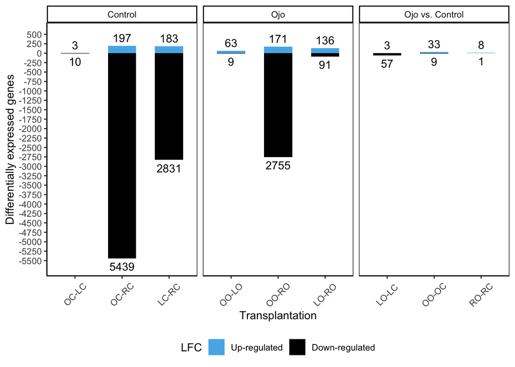

```r
plot.combo <- ggplot(summary2, aes(x = group, fill = LFC)) +
  facet_wrap(~Destination, scales = "free_x") +
  geom_bar(data=subset(summary2, LFC=="Up"), aes(y=n, fill = LFC), stat = "identity", width=0.6) + #, binwidth=0
  geom_bar(data=subset(summary2, LFC=="Down"), aes(y=n, fill = LFC), stat = "identity", width=0.6) + #, binwidth=0
  geom_text(data=subset(summary2, LFC=="Up"), aes(group, n, label = n), position = position_dodge(width=0.9), vjust = -0.5) +
  geom_text(data=subset(summary2, LFC=="Down"), aes(group, n, label = -n), position = position_dodge(width=0.9), vjust = 1.5) +
  scale_fill_manual("LFC", values=c("black", "#56B4E9"), labels=c("Down-regulated", "Up-regulated"), guide=guide_legend(reverse=TRUE)) + #colorblind friendly
  ylab("Differentially expressed genes") +
  xlab("Transplantation") +
  scale_y_continuous(limits = c(-5600, 500), breaks = seq(-5500, 500, by = 250)) +
  theme_classic() +
  theme(legend.position = "bottom", panel.background = element_rect(colour = "black"), axis.text.x = element_text(angle = 45, vjust = 0.5)) #axis.text.x=element_text(vjust=0.5, size=10, face="italic"),

plot.combo
```

```r
# save plot
ggsave("Sid_Symbiont_C_DEG_barplot.pdf", plot = plot.combo,  width = 5, height = 4, units = "in", dpi = 1200) #width = 6.5, height = 4.5
```

## with low pH vs. ambient pH pairwise contrasts that *do not have comparative site contrast*

OO_RC OO_LC

```r
summary3 <- rbind(summary_DEG_1, summary_DEG_2, summary_DEG_3, summary_DEG_4, summary_DEG_5, summary_DEG_6, summary_DEG_7, summary_DEG_8, summary_DEG_9, summary_DEG_10, summary_DEG_11)

summary3
```

```
## # A tibble: 22 x 3
##    group LFC       n
##    <fct> <fct> <int>
##  1 OC-LC Down    -10
##  2 OC-LC Up        3
##  3 OC-RC Down  -5439
##  4 OC-RC Up      197
##  5 LC-RC Down  -2831
##  6 LC-RC Up      183
##  7 OO-LO Down     -9
##  8 OO-LO Up       63
##  9 LO-RO Down    -91
## 10 LO-RO Up      136
## # … with 12 more rows
```

```r
summary3$Destination <- c("Control", "Control", "Control", "Control", "Control", "Control", "Ojo", "Ojo", "Ojo", "Ojo", "Ojo", "Ojo", "Ojo vs. Control", "Ojo vs. Control", "Ojo vs. Control", "Ojo vs. Control", "Ojo vs. Control", "Ojo vs. Control", "Low vs. Ambient pH", "Low vs. Ambient pH", "Low vs. Ambient pH", "Low vs. Ambient pH")

summary3$Destination <- as.factor(summary3$Destination)
summary3$Destination <- factor(summary3$Destination, levels = c("Control", "Ojo", "Ojo vs. Control", "Low vs. Ambient pH"))

summary3
```

```
## # A tibble: 22 x 4
##    group LFC       n Destination
##    <fct> <fct> <int> <fct>
##  1 OC-LC Down    -10 Control
##  2 OC-LC Up        3 Control
##  3 OC-RC Down  -5439 Control
##  4 OC-RC Up      197 Control
##  5 LC-RC Down  -2831 Control
##  6 LC-RC Up      183 Control
##  7 OO-LO Down     -9 Ojo
##  8 OO-LO Up       63 Ojo
##  9 LO-RO Down    -91 Ojo
## 10 LO-RO Up      136 Ojo
## # … with 12 more rows
```

```r
# "OC-LC" "OC-RC" "LC-RC" "OO-LO" "LO-RO" "OO-RO" "LO-LC" "OO-OC" "RO-RC" "OO-RC" "OO-LC"
summary3$group <- factor(summary3$group, levels = c("OC-LC", "OC-RC", "LC-RC", "OO-LO", "OO-RO", "LO-RO", "LO-LC", "OO-OC", "RO-RC", "OO-RC", "OO-LC"))
```

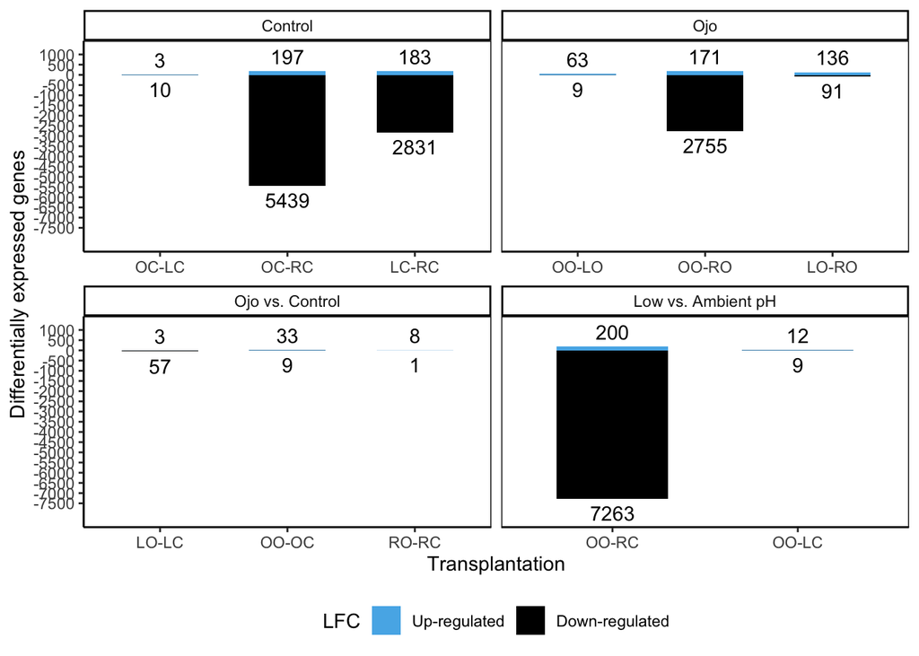

```r
plot.combo <- ggplot(summary3, aes(x = group, fill = LFC)) +
  facet_wrap(~Destination, scales = "free_x") +
  geom_bar(data=subset(summary3, LFC=="Up"), aes(y=n, fill = LFC), stat = "identity", width=0.6) + #, binwidth=0
  geom_bar(data=subset(summary3, LFC=="Down"), aes(y=n, fill = LFC), stat = "identity", width=0.6) + #, binwidth=0
  geom_text(data=subset(summary3, LFC=="Up"), aes(group, n, label = n), position = position_dodge(width=0.9), vjust = -0.5) +
  geom_text(data=subset(summary3, LFC=="Down"), aes(group, n, label = -n), position = position_dodge(width=0.9), vjust = 1.5) +
  scale_fill_manual("LFC", values=c("black", "#56B4E9"), labels=c("Down-regulated", "Up-regulated"), guide=guide_legend(reverse=TRUE)) + #colorblind friendly
  ylab("Differentially expressed genes") +
  xlab("Transplantation") +
  scale_y_continuous(limits = c(-8200, 1200), breaks = seq(-7500, 1000, by = 500)) +
  theme_classic() +
  theme(legend.position = "bottom", panel.background = element_rect(colour = "black")) #axis.text.x=element_text(vjust=0.5, size=10, face="italic"),

plot.combo
```

```r
# save plot
#ggsave("Sid_Symbiont_C_DEG_barplot_4-dest-comparisons.pdf", plot = plot.combo,  width = 5, height = 4, units = "in", dpi = 1200) #width = 6.5, height = 4.5
```